# Appendix D. Cumulative impacts of mining and wind power development on reindeer: calving-site selection data and analysis

# 4 Table D2: Final model results

Here we show the coefficients for the best-ranked model. The second and third-ranked models had similar support from the data and only differed in the scale of the TPI considered; all other coefficients were similar.

|  | term | estimate | std.error | p | select |
| --- | --- | --- | --- | --- | --- |
| 1 | (Intercept) | -4.786 | 1.739 | 0.006 | avoidance/negative |
| 2 | scale(dem) | -0.46 | 0.111 | &lt;0.001 | avoidance/negative |
| 3 | I(scale(dem)^2) | -0.3 | 0.093 | 0.001 | avoidance/negative |
| 4 | scale(slope) | -0.15 | 0.102 | 0.144 | no effect |
| 5 | cos_aspect | 0.183 | 0.114 | 0.108 | no effect |
| 6 | log(priv_road_dist + 1) | 0.325 | 0.089 | &lt;0.001 | avoidance/negative |
| 7 | log(public_road_dist + 1) | 0.303 | 0.088 | 0.001 | avoidance/negative |
| 8 | tpi_s250m | 0.085 | 0.03 | 0.005 | selection/positive |
| 9 | scale(mining_Krist_nearest10000) | -1.38 | 0.411 | 0.001 | avoidance/negative |
| 10 | landcover_ccconiferous forests | 0.132 | 1.076 | 0.903 | no effect |

[output cut: 8 more lines]

Table D2. Coefficient estimates of the most parsimonious generalized linear model testing the effect of infrastructures on reindeer calving site selection from the Malå reindeer herding community between 2008 and 2018. The table includes the estimates, the standard error (std.error) and the p-values (p).

# 5 Figure D2: Difference across years and phase in calving dates and between females that had been close to the wind turbines and those that had not

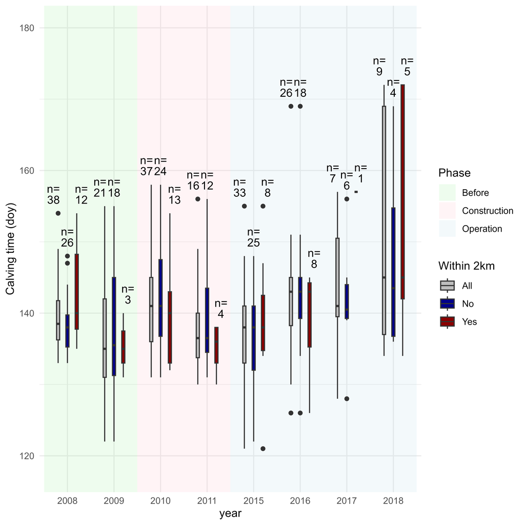

Figure D2. Distribution of individual females’ calving time (day of the year, doy, when calving occured) in the Malå reindeer herding community from 2008 to 2018 according to year. The colors in the background represent the phase of construction of wind power plants (Before construction, during construction, during operation). Colors in the plots represent the distribution of all individuals, only those within 2km of the wind turbines during the calving period, and only those that were always more than 2km away. The results of the Kruskal-Wallis test showed no significant difference according to proximity or among phases for individuals who have been roaming close to the wind turbines during calving.

# 6 Figure D3: Synchrony between calving date and forage quality

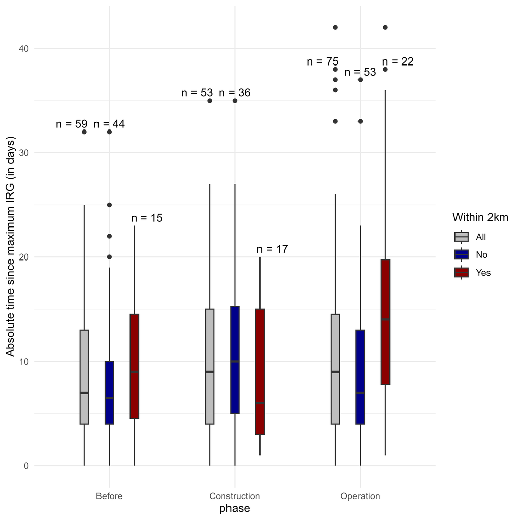